# 데이터 분석 기본 - pandas

# 집계함수

```python
# 인사 데이터
df = pd.read_csv('./datas/fake_company.csv')
df
```

|  | Year | Name | Department | Age | Salary |
| --- | --- | --- | --- | --- | --- |
| 0 | 1990 | Alice | HR | 25 | 50000 |
| 1 | 1990 | Bob | RD | 30 | 48000 |
| 2 | 1990 | Charlie | Admin | 45 | 55000 |
| 3 | 1991 | Alice | HR | 26 | 52000 |
| 4 | 1991 | Bob | RD | 31 | 50000 |
| 5 | 1991 | Charlie | Admin | 46 | 60000 |
| 6 | 1992 | Alice | HR | 27 | 60000 |
| 7 | 1992 | Bob | RD | 32 | 52000 |
| 8 | 1992 | Charlie | Admin | 47 | 62000 |

```python
df.describe()
```

|  | Year | Age | Salary |
| --- | --- | --- | --- |
| count | 9.000000 | 9.000000 | 9.000000 |
| mean | 1991.000000 | 34.333333 | 54333.333333 |
| std | 0.866025 | 9.055385 | 5147.815070 |
| min | 1990.000000 | 25.000000 | 48000.000000 |
| 25% | 1990.000000 | 27.000000 | 50000.000000 |
| 50% | 1991.000000 | 31.000000 | 52000.000000 |
| 75% | 1992.000000 | 45.000000 | 60000.000000 |
| max | 1992.000000 | 47.000000 | 62000.000000 |

```python
df.shape
```

```
(9, 5)
```

## 중복데이터 처리

```python
df
```

|  | Year | Name | Department | Age | Salary |
| --- | --- | --- | --- | --- | --- |
| 0 | 1990 | Alice | HR | 25 | 50000 |
| 1 | 1990 | Bob | RD | 30 | 48000 |
| 2 | 1990 | Charlie | Admin | 45 | 55000 |
| 3 | 1991 | Alice | HR | 26 | 52000 |
| 4 | 1991 | Bob | RD | 31 | 50000 |
| 5 | 1991 | Charlie | Admin | 46 | 60000 |
| 6 | 1992 | Alice | HR | 27 | 60000 |
| 7 | 1992 | Bob | RD | 32 | 52000 |
| 8 | 1992 | Charlie | Admin | 47 | 62000 |

```python
# 중복된 데이터가 있을 것을, 범주형(카테고리컬; categorical) 데이터라고 함.
```

```python
# 중복 제거하는 함수
df['Year'].unique()
```

```
array([1990, 1991, 1992])
```

```python
df
```

|  | Year | Name | Department | Age | Salary |
| --- | --- | --- | --- | --- | --- |
| 0 | 1990 | Alice | HR | 25 | 50000 |
| 1 | 1990 | Bob | RD | 30 | 48000 |
| 2 | 1990 | Charlie | Admin | 45 | 55000 |
| 3 | 1991 | Alice | HR | 26 | 52000 |
| 4 | 1991 | Bob | RD | 31 | 50000 |
| 5 | 1991 | Charlie | Admin | 46 | 60000 |
| 6 | 1992 | Alice | HR | 27 | 60000 |
| 7 | 1992 | Bob | RD | 32 | 52000 |
| 8 | 1992 | Charlie | Admin | 47 | 62000 |

```python
# 각 년도별로 연봉 총합을 구하라
df.groupby('Year')['Salary'].sum()
```

```
Year
1990    153000
1991    162000
1992    174000
Name: Salary, dtype: int64
```

```python
# 각 직원별로 연봉평균을 구하라.
df
```

|  | Year | Name | Department | Age | Salary |
| --- | --- | --- | --- | --- | --- |
| 0 | 1990 | Alice | HR | 25 | 50000 |
| 1 | 1990 | Bob | RD | 30 | 48000 |
| 2 | 1990 | Charlie | Admin | 45 | 55000 |
| 3 | 1991 | Alice | HR | 26 | 52000 |
| 4 | 1991 | Bob | RD | 31 | 50000 |
| 5 | 1991 | Charlie | Admin | 46 | 60000 |
| 6 | 1992 | Alice | HR | 27 | 60000 |
| 7 | 1992 | Bob | RD | 32 | 52000 |
| 8 | 1992 | Charlie | Admin | 47 | 62000 |

```python
df.groupby('Name')['Salary'].mean()
```

```
Name
Alice      54000.0
Bob        50000.0
Charlie    59000.0
Name: Salary, dtype: float64
```

```python
# 년도별로 묶되 년도가 같으면 부서별로 연봉 총합 구하세요.
df.groupby(['Year', 'Department'])['Salary'].sum()
```

```
Year  Department
1990  Admin         55000
      HR            50000
      RD            48000
1991  Admin         60000
      HR            52000
      RD            50000
1992  Admin         62000
      HR            60000
      RD            52000
Name: Salary, dtype: int64
```

```python
# 년도별로, 연봉 총합도 보여주고, 연봉 평균도 보여달라.
df.groupby('Year')['Salary'].agg(['sum', 'mean'])
```

| Year | sum | mean |
| --- | --- | --- |
| 1990 | 153000 | 51000.0 |
| 1991 | 162000 | 54000.0 |
| 1992 | 174000 | 58000.0 |

- 실무 tip

```python
# 카테고리컬 데이터의 데이터별로 갯수를 확인하는 방법
# select Year, count(*) from df group by Year;

df.groupby(['Year'])['Year'].count()
```

```
Year
1990    3
1991    3
1992    3
Name: Year, dtype: int64
```

```python
# 이렇게 데이터별로  개수를 세는 것은 데이터분석에 많이 사용하므로, 전용함수가 있음.
df['Year'].value_counts()
```

```
Year
1990    3
1991    3
1992    3
Name: count, dtype: int64
```

# GETTING HTML DATA

```python
# pip install lxml
```

```python
# 캐나다 집값 정보
df_html = pd.read_html('https://www.livingin-canada.com/house-prices-canada.html')
type(df_html)
```

```
list
```

```python
df_html
```

[output not shown]

[output cut: 58 more lines]

```python
df1 = df_html[0]
df1
```

|  | City | Average House Price | 12 Month Change |
| --- | --- | --- | --- |
| 0 | Vancouver, BC | $1,036,000 | + 2.63 % |
| 1 | Toronto, Ont | $870,000 | +10.2 % |
| 2 | Ottawa, Ont | $479,000 | + 15.4 % |
| 3 | Calgary, Alb | $410,000 | – 1.5 % |
| 4 | Montreal, Que | $435,000 | + 9.3 % |
| 5 | Halifax, NS | $331,000 | + 3.6 % |
| 6 | Regina, Sask | $254,000 | – 3.9 % |
| 7 | Fredericton, NB | $198,000 | – 4.3 % |
| 8 | (adsbygoogle = window.adsbygoogle \|\| []).push(... | (adsbygoogle = window.adsbygoogle \|\| []).push(... | (adsbygoogle = window.adsbygoogle \|\| []).push(... |

```python
df1.shape
```

```
(9, 3)
```

```python
# 마지막 행 삭제
df1 = df1.drop(8)
df1
```

|  | City | Average House Price | 12 Month Change |
| --- | --- | --- | --- |
| 0 | Vancouver, BC | $1,036,000 | + 2.63 % |
| 1 | Toronto, Ont | $870,000 | +10.2 % |
| 2 | Ottawa, Ont | $479,000 | + 15.4 % |
| 3 | Calgary, Alb | $410,000 | – 1.5 % |
| 4 | Montreal, Que | $435,000 | + 9.3 % |
| 5 | Halifax, NS | $331,000 | + 3.6 % |
| 6 | Regina, Sask | $254,000 | – 3.9 % |
| 7 | Fredericton, NB | $198,000 | – 4.3 % |

```python
df2 = df_html[1]
df2
```

|  | Province | Average House Price | 12 Month Change |
| --- | --- | --- | --- |
| 0 | British Columbia | $736,000 | + 7.6 % |
| 1 | Ontario | $594,000 | – 3.2 % |
| 2 | Alberta | $353,000 | – 7.5 % |
| 3 | Quebec | $340,000 | + 7.6 % |
| 4 | Manitoba | $295,000 | – 1.4 % |
| 5 | Saskatchewan | $271,000 | – 3.8 % |
| 6 | Nova Scotia | $266,000 | + 3.5 % |
| 7 | Prince Edward Island | $243,000 | + 3.0 % |
| 8 | Newfoundland / Labrador | $236,000 | – 1.6 % |
| 9 | New Brunswick | $183,000 | – 2.2 % |
| 10 | Canadian Average | $488,000 | – 1.3 % |
| 11 | (adsbygoogle = window.adsbygoogle \|\| []).push(... | (adsbygoogle = window.adsbygoogle \|\| []).push(... | (adsbygoogle = window.adsbygoogle \|\| []).push(... |

```python
# 마지막 행 삭제
df2 = df2.drop(11)
df2
```

|  | Province | Average House Price | 12 Month Change |
| --- | --- | --- | --- |
| 0 | British Columbia | $736,000 | + 7.6 % |
| 1 | Ontario | $594,000 | – 3.2 % |
| 2 | Alberta | $353,000 | – 7.5 % |
| 3 | Quebec | $340,000 | + 7.6 % |
| 4 | Manitoba | $295,000 | – 1.4 % |
| 5 | Saskatchewan | $271,000 | – 3.8 % |
| 6 | Nova Scotia | $266,000 | + 3.5 % |
| 7 | Prince Edward Island | $243,000 | + 3.0 % |
| 8 | Newfoundland / Labrador | $236,000 | – 1.6 % |
| 9 | New Brunswick | $183,000 | – 2.2 % |
| 10 | Canadian Average | $488,000 | – 1.3 % |

# PANDAS OPERATIONS

- 어떤 조건에 맞는 데이터를 가져오는 방법

```python
# 데이터 프레임 만들기
df = pd.DataFrame({'Employee ID':[111, 222, 333, 444],
                   'Employee Name':['Chanel', 'Steve', 'Mitch', 'Bird'],
                   'Salary [$/h]':[35, 29, 38, 20],
                   'Years of Experience':[3, 4 ,9, 1]})
df
```

|  | Employee ID | Employee Name | Salary [$/h] | Years of Experience |
| --- | --- | --- | --- | --- |
| 0 | 111 | Chanel | 35 | 3 |
| 1 | 222 | Steve | 29 | 4 |
| 2 | 333 | Mitch | 38 | 9 |
| 3 | 444 | Bird | 20 | 1 |

```python
# 경력이 3년 이상인 사람의 데이터를 가져오기
df[df['Years of Experience'] >= 3]
```

|  | Employee ID | Employee Name | Salary [$/h] | Years of Experience |
| --- | --- | --- | --- | --- |
| 0 | 111 | Chanel | 35 | 3 |
| 1 | 222 | Steve | 29 | 4 |
| 2 | 333 | Mitch | 38 | 9 |

```python
# 경력이 3년 이상인 사람의 데이터 가져오기
# df.loc[, ]
df.loc[df['Years of Experience'] >= 3]
```

|  | Employee ID | Employee Name | Salary [$/h] | Years of Experience |
| --- | --- | --- | --- | --- |
| 0 | 111 | Chanel | 35 | 3 |
| 1 | 222 | Steve | 29 | 4 |
| 2 | 333 | Mitch | 38 | 9 |

```python
df.loc[df['Years of Experience'] >= 3, ['Employee Name', 'Salary [$/h]', 'Years of Experience']]
```

|  | Employee Name | Salary [$/h] | Years of Experience |
| --- | --- | --- | --- |
| 0 | Chanel | 35 | 3 |
| 1 | Steve | 29 | 4 |
| 2 | Mitch | 38 | 9 |

```python
# 이렇게 쓰면 안됨
df.iloc[df['Years of Experience'] >= 3]
```

[output not shown]

- 경력이 3년 이상이고, 시급이 30달러 이상인 사람의 데이터를 가져오기

```python
df
```

|  | Employee ID | Employee Name | Salary [$/h] | Years of Experience |
| --- | --- | --- | --- | --- |
| 0 | 111 | Chanel | 35 | 3 |
| 1 | 222 | Steve | 29 | 4 |
| 2 | 333 | Mitch | 38 | 9 |
| 3 | 444 | Bird | 20 | 1 |

```python
# 조건
df['Years of Experience'] >=3
```

```
0     True
1     True
2     True
3    False
Name: Years of Experience, dtype: bool
```

```python
# 조건
df['Salary [$/h]'] >= 30
```

```
0     True
1    False
2     True
3    False
Name: Salary [$/h], dtype: bool
```

```python
# and 오류남
(df['Years of Experience'] >=3) & (df['Salary [$/h]'] >= 30)
```

```
0     True
1    False
2     True
3    False
dtype: bool
```

```python
# True인 행을 가져옴 =>  .loc[,] 에서 콤마의 왼쪽 행자리에 적어준다.
```

```python
df.loc[(df['Years of Experience'] >=3) & (df['Salary [$/h]'] >= 30)]
```

|  | Employee ID | Employee Name | Salary [$/h] | Years of Experience |
| --- | --- | --- | --- | --- |
| 0 | 111 | Chanel | 35 | 3 |
| 2 | 333 | Mitch | 38 | 9 |

```python
# 이 사람의 이름만 가져오기
df.loc[(df['Years of Experience'] >=3) & (df['Salary [$/h]'] >= 30), 'Employee Name']
```

```
0    Chanel
2     Mitch
Name: Employee Name, dtype: object
```

```python
df.loc[(df['Years of Experience'] >=3) & (df['Salary [$/h]'] >= 30), ['Employee Name', 'Years of Experience']]
```

|  | Employee Name | Years of Experience |
| --- | --- | --- |
| 0 | Chanel | 3 |
| 2 | Mitch | 9 |

- 경력이 3년 이하이거나 8년 이상인 사람의 데이터를 가져오기
- 거나, or에 해당되는 것은 | 기호를 사용함.

```python
df
```

|  | Employee ID | Employee Name | Salary [$/h] | Years of Experience |
| --- | --- | --- | --- | --- |
| 0 | 111 | Chanel | 35 | 3 |
| 1 | 222 | Steve | 29 | 4 |
| 2 | 333 | Mitch | 38 | 9 |
| 3 | 444 | Bird | 20 | 1 |

```python
(df['Years of Experience'] <=3) | (df['Years of Experience'] >=8 )
```

```
0     True
1    False
2     True
3     True
Name: Years of Experience, dtype: bool
```

```python
# df.loc[행, 열]
df.loc[(df['Years of Experience'] <=3) | (df['Years of Experience'] >=8 ), ['Employee Name', 'Years of Experience']]
```

|  | Employee Name | Years of Experience |
| --- | --- | --- |
| 0 | Chanel | 3 |
| 2 | Mitch | 9 |
| 3 | Bird | 1 |

통계값으로 비교해서 가져오기

```python
df
```

|  | Employee ID | Employee Name | Salary [$/h] | Years of Experience |
| --- | --- | --- | --- | --- |
| 0 | 111 | Chanel | 35 | 3 |
| 1 | 222 | Steve | 29 | 4 |
| 2 | 333 | Mitch | 38 | 9 |
| 3 | 444 | Bird | 20 | 1 |

- 시급이 가장 높은 사람의 데이터 가져오기

```python
# 1. 최대값을 먼저 찾는다.
df['Salary [$/h]'].max()
```

```
38
```

```python
# 2. 시급컬럼에서, 위에서 찾은 최대값과 같은 데이터를 찾음.
(df['Salary [$/h]'] == df['Salary [$/h]'].max())
```

```
0    False
1    False
2     True
3    False
Name: Salary [$/h], dtype: bool
```

```python
# 3. 위에서 True인 행을 가져옴
df.loc[(df['Salary [$/h]'] == df['Salary [$/h]'].max()), : ]
```

|  | Employee ID | Employee Name | Salary [$/h] | Years of Experience |
| --- | --- | --- | --- | --- |
| 2 | 333 | Mitch | 38 | 9 |

# [실습 2]

- 1.b[실습1]pandas기본_와인분석.ipynb

# APPLYING FUNCTIONS

```python
df
```

|  | Employee ID | Employee Name | Salary [$/h] | Years of Experience |
| --- | --- | --- | --- | --- |
| 0 | 111 | Chanel | 35 | 3 |
| 1 | 222 | Steve | 29 | 4 |
| 2 | 333 | Mitch | 38 | 9 |
| 3 | 444 | Bird | 20 | 1 |

```python
# 직원 이름은 몇글자인지, 글자수를 세어서, 새로운 커럼 length 컬럼에 저장하자.
# 실무에 많이 쓰는 기능
# https://pandas.pydata.org/docs/reference/api/pandas.Series.str.upper.html

# df['Employee Name'].str  <- 시리즈의 각 요소을 지정함

# 모두 대문자로
df['Employee Name'].str.upper()
```

```
0    CHANEL
1     STEVE
2     MITCH
3      BIRD
Name: Employee Name, dtype: object
```

```python
# 첫글자만 대문자로
df['Employee Name'].str.title()
```

```
0    Chanel
1     Steve
2     Mitch
3      Bird
Name: Employee Name, dtype: object
```

```python
# https://pandas.pydata.org/docs/reference/api/pandas.Series.str.len.html
df['Employee Name'].str.len()
```

```
0    6
1    5
2    5
3    4
Name: Employee Name, dtype: int64
```

```python
# 이름의 길이를 계산해서 컬럼으로 추가하기
df['name_length']= df['Employee Name'].str.len()
df
```

|  | Employee ID | Employee Name | Salary [$/h] | Years of Experience | name_length |
| --- | --- | --- | --- | --- | --- |
| 0 | 111 | Chanel | 35 | 3 | 6 |
| 1 | 222 | Steve | 29 | 4 | 5 |
| 2 | 333 | Mitch | 38 | 9 | 5 |
| 3 | 444 | Bird | 20 | 1 | 4 |

- 조건에 따른 데이터 가공

```python
# 시급이 30보다 이상이면 'A'
# 시급이 30보다 작으면 'B'
# 이렇게 새로운 컬럼 group 컬럼을 만들어서 데이터를 셋팅하세요.
```

```python
df
```

|  | Employee ID | Employee Name | Salary [$/h] | Years of Experience | name_length |
| --- | --- | --- | --- | --- | --- |
| 0 | 111 | Chanel | 35 | 3 | 6 |
| 1 | 222 | Steve | 29 | 4 | 5 |
| 2 | 333 | Mitch | 38 | 9 | 5 |
| 3 | 444 | Bird | 20 | 1 | 4 |

```python
def get_group(salary):
    if salary  > 30 :
        return 'A'
    elif salary  < 30 :
        return 'B'
```

```python
get_group(40)
# A
```

```
'A'
```

```python
get_group(20)
# B
```

```
'B'
```

```python
df
```

|  | Employee ID | Employee Name | Salary [$/h] | Years of Experience | name_length |
| --- | --- | --- | --- | --- | --- |
| 0 | 111 | Chanel | 35 | 3 | 6 |
| 1 | 222 | Steve | 29 | 4 | 5 |
| 2 | 333 | Mitch | 38 | 9 | 5 |
| 3 | 444 | Bird | 20 | 1 | 4 |

```python
df['Salary [$/h]'].apply(get_group)
```

```
0    A
1    B
2    A
3    B
Name: Salary [$/h], dtype: object
```

```python
df['Group'] = df['Salary [$/h]'].apply(get_group)
```

```python
df
```

|  | Employee ID | Employee Name | Salary [$/h] | Years of Experience | name_length | Group |
| --- | --- | --- | --- | --- | --- | --- |
| 0 | 111 | Chanel | 35 | 3 | 6 | A |
| 1 | 222 | Steve | 29 | 4 | 5 | B |
| 2 | 333 | Mitch | 38 | 9 | 5 | A |
| 3 | 444 | Bird | 20 | 1 | 4 | B |

## [실습]

- 1.b[실습2]pandas기본_와인분석.ipynb

# SORTING(정렬)

```python
df = pd.DataFrame({'Employee ID':[111, 222, 333, 444],
                   'Employee Name':['Chanel', 'Steve', 'Mitch', 'Bird'],
                   'Salary [$/h]':[35, 29, 38, 20],
                   'Years of Experience':[3, 4 ,9, 1]})
df
```

|  | Employee ID | Employee Name | Salary [$/h] | Years of Experience |
| --- | --- | --- | --- | --- |
| 0 | 111 | Chanel | 35 | 3 |
| 1 | 222 | Steve | 29 | 4 |
| 2 | 333 | Mitch | 38 | 9 |
| 3 | 444 | Bird | 20 | 1 |

```python
df.sort_values(by='Salary [$/h]', ascending=True)
```

|  | Employee ID | Employee Name | Salary [$/h] | Years of Experience |
| --- | --- | --- | --- | --- |
| 3 | 444 | Bird | 20 | 1 |
| 1 | 222 | Steve | 29 | 4 |
| 0 | 111 | Chanel | 35 | 3 |
| 2 | 333 | Mitch | 38 | 9 |

```python
df.sort_values(by='Salary [$/h]', ascending=False)
```

|  | Employee ID | Employee Name | Salary [$/h] | Years of Experience |
| --- | --- | --- | --- | --- |
| 2 | 333 | Mitch | 38 | 9 |
| 0 | 111 | Chanel | 35 | 3 |
| 1 | 222 | Steve | 29 | 4 |
| 3 | 444 | Bird | 20 | 1 |

# CONCATENATING AND MERGING

## Concate(합치기)

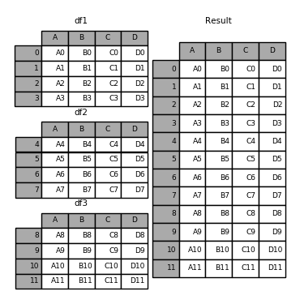

Reference: https://pandas.pydata.org/pandas-docs/stable/merging.html

```python
df1 = pd.DataFrame({'A': ['A0', 'A1', 'A2', 'A3'],
                    'B': ['B0', 'B1', 'B2', 'B3'],
                    'C': ['C0', 'C1', 'C2', 'C3'],
                    'D': ['D0', 'D1', 'D2', 'D3']},
index=[0, 1, 2, 3])
df1
```

|  | A | B | C | D |
| --- | --- | --- | --- | --- |
| 0 | A0 | B0 | C0 | D0 |
| 1 | A1 | B1 | C1 | D1 |
| 2 | A2 | B2 | C2 | D2 |
| 3 | A3 | B3 | C3 | D3 |

```python
df2 = pd.DataFrame({'A': ['A4', 'A5', 'A6', 'A7'],
                    'B': ['B4', 'B5', 'B6', 'B7'],
                    'C': ['C4', 'C5', 'C6', 'C7'],
                    'D': ['D4', 'D5', 'D6', 'D7']},
index=[4, 5, 6, 7])
df2
```

|  | A | B | C | D |
| --- | --- | --- | --- | --- |
| 4 | A4 | B4 | C4 | D4 |
| 5 | A5 | B5 | C5 | D5 |
| 6 | A6 | B6 | C6 | D6 |
| 7 | A7 | B7 | C7 | D7 |

```python
df3 = pd.DataFrame({'A': ['A8', 'A9', 'A10', 'A11'],
                    'B': ['B8', 'B9', 'B10', 'B11'],
                    'C': ['C8', 'C9', 'C10', 'C11'],
                    'D': ['D8', 'D9', 'D10', 'D11']},
index=[8, 9, 10, 11])

df3
```

|  | A | B | C | D |
| --- | --- | --- | --- | --- |
| 8 | A8 | B8 | C8 | D8 |
| 9 | A9 | B9 | C9 | D9 |
| 10 | A10 | B10 | C10 | D10 |
| 11 | A11 | B11 | C11 | D11 |

```python
pd.concat([df1, df2, df3], axis=0)
```

|  | A | B | C | D |
| --- | --- | --- | --- | --- |
| 0 | A0 | B0 | C0 | D0 |
| 1 | A1 | B1 | C1 | D1 |
| 2 | A2 | B2 | C2 | D2 |
| 3 | A3 | B3 | C3 | D3 |
| 4 | A4 | B4 | C4 | D4 |
| 5 | A5 | B5 | C5 | D5 |
| 6 | A6 | B6 | C6 | D6 |
| 7 | A7 | B7 | C7 | D7 |
| 8 | A8 | B8 | C8 | D8 |
| 9 | A9 | B9 | C9 | D9 |
| 10 | A10 | B10 | C10 | D10 |
| 11 | A11 | B11 | C11 | D11 |

```python
pd.concat([df1, df2, df3], axis=1)
```

|  | A | B | C | D | A | B | C | D | A | B | C | D |
| --- | --- | --- | --- | --- | --- | --- | --- | --- | --- | --- | --- | --- |
| 0 | A0 | B0 | C0 | D0 | NaN | NaN | NaN | NaN | NaN | NaN | NaN | NaN |
| 1 | A1 | B1 | C1 | D1 | NaN | NaN | NaN | NaN | NaN | NaN | NaN | NaN |
| 2 | A2 | B2 | C2 | D2 | NaN | NaN | NaN | NaN | NaN | NaN | NaN | NaN |
| 3 | A3 | B3 | C3 | D3 | NaN | NaN | NaN | NaN | NaN | NaN | NaN | NaN |
| 4 | NaN | NaN | NaN | NaN | A4 | B4 | C4 | D4 | NaN | NaN | NaN | NaN |
| 5 | NaN | NaN | NaN | NaN | A5 | B5 | C5 | D5 | NaN | NaN | NaN | NaN |
| 6 | NaN | NaN | NaN | NaN | A6 | B6 | C6 | D6 | NaN | NaN | NaN | NaN |
| 7 | NaN | NaN | NaN | NaN | A7 | B7 | C7 | D7 | NaN | NaN | NaN | NaN |
| 8 | NaN | NaN | NaN | NaN | NaN | NaN | NaN | NaN | A8 | B8 | C8 | D8 |
| 9 | NaN | NaN | NaN | NaN | NaN | NaN | NaN | NaN | A9 | B9 | C9 | D9 |
| 10 | NaN | NaN | NaN | NaN | NaN | NaN | NaN | NaN | A10 | B10 | C10 | D10 |
| 11 | NaN | NaN | NaN | NaN | NaN | NaN | NaN | NaN | A11 | B11 | C11 | D11 |